# AnalisisPlanilla

*Lo que acordamos la última reunión:*

¿Cuántos ecopuntos hay? Hicimos la excepciòn del ecopunto Reaccionar porque es de nuestro interés. Aclarar que fuimos a relevar 31 puntos verdes promocionados/publicados por la municipalidad. De ahí responder: ¿Cuántos se encuentran inactivos, cuántos no se observan, cuántos no fueron en realidad ecopuntos? ¿A qué se debía? Aclarar de cada ítem de qué se trata.

¿Cuál fue la accesibilidad observada, temporal y espacialmente? gráficos ¿Tiene que ver la cartelería con que no se pudo observar el ecopunto? Aclarar las variables de accesibilidad.

¿Se encuentran contaminados? ¿Hay cartelería? ¿Qué día de la semana era? (Sobre todo para los que están activos)

Para què?? concientizar?? Propuesta??

PASAR A TEXTO!!

# Estado actual

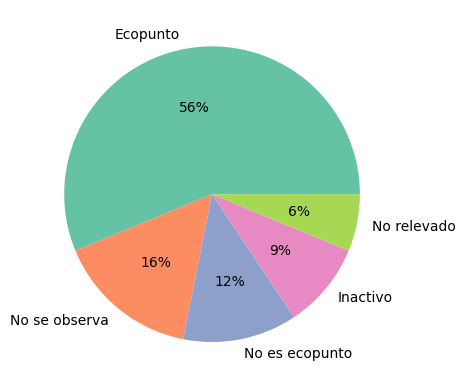

De 32 ecopuntos que aparecen en la página de la municipalidad, 56% encontramos que realmente funcionaban como ecopuntos, 16% no se pudo observar, ya que no se pudo acceder para ver si realmente había un ecopunto dentro de la instalación marcada, 12% encontramos que ya no funcionaban comom ecopuntos, 9% se aclaraba en el mapa que podrían estar inactivos, y 6% no fueron relevados.

# Accesibilidad

Una buena accesibilidad espacial asume que cualquier ciudadano puede visualizar el contenedor de residuos reciclables fácilmente sin que exista alguna barrera física al espacio público.

### Accesibilidad espacial de ecopuntos activos y de aquellos que no se pudieron observar

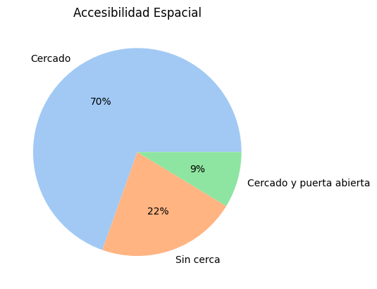

De los ecopuntos que se relevaron y son ecopuntos o podrían serlo, 70% se encontraban cercados, es decir, hay alguna reja, pared, o cualquier elemento divisorio en el camino para acceder al ecopunto, 22% se encontraba sin cerca y 9% tenían cerca pero sin embargo había una entrada que permanecía abierta.

¿Cómo se relaciona la accesibilidad con el estado del ecopunto?

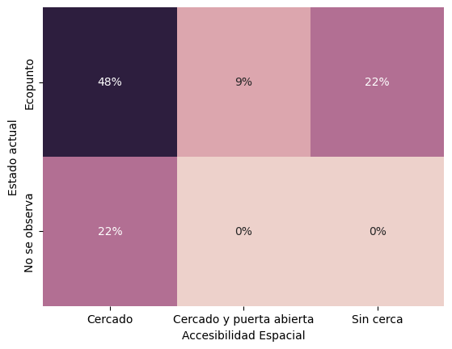

De todos los ecopuntos que no se pudieron observar todos estaban cercados, mientras que de los ecopuntos que finalmente se pudieron relevar, en su mayor parte estaban cercados de igual forma (pueden incluirse ecopuntos que no se observaron directamente si no desde lejos).

Una buena accesibilidad temporal supone que no hay límites de horario ni días específicos para poder ir a depositar material reciclable.

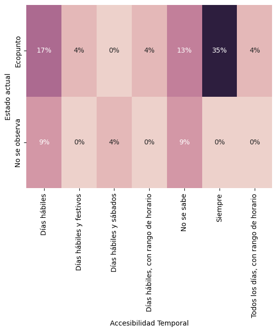

De la todos los ecopuntos que relevamos y que deberíamos haber relevado, el 35% era un ecopunto como tal y se encontraban abiertos siempre, no es un porcentaje elevado. Pues, le siguen los ecopuntos que aunque sea de lejos se pudo observar pero que sabíamos que se encontraban abiertos los días hábiles.

De los que no pudimos observar, el 13% estaban abiertos los días hábiles o días hábiles y sábados y del resto no sabemos (tampoco había cartelería para saberlo)

¿Son aislados los distintos tipos de accesibilidad?

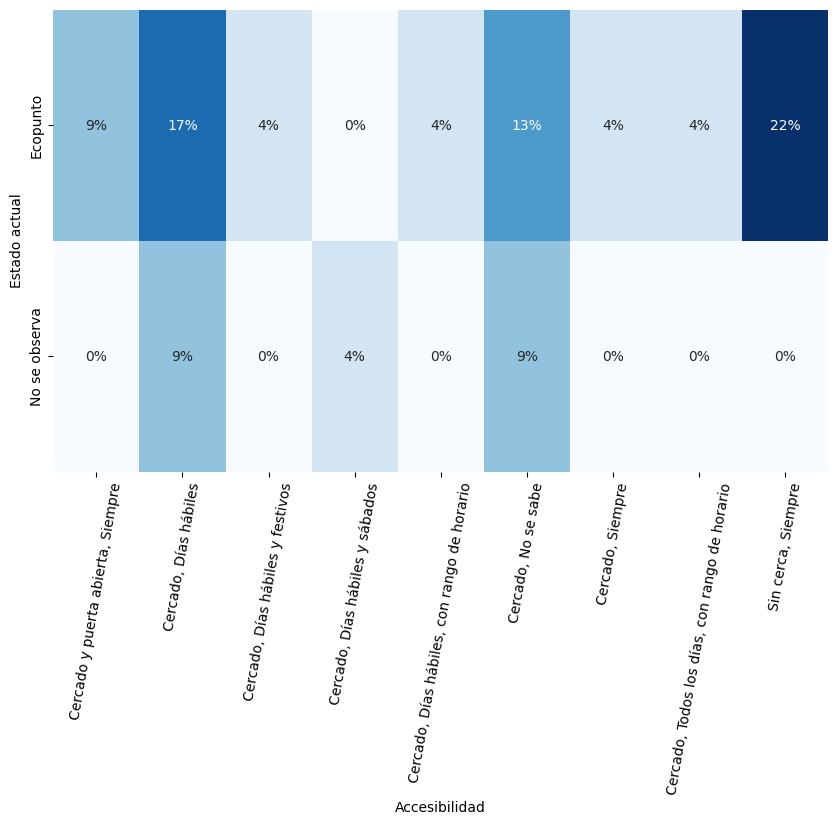

Vemos que de todos los ecopuntos relevados solo el 22% funcionaba realmente como un ecopunto y era totatlmete accesible, lo que no marca una gran frecuencia dentro de la población ya que muy cerca se encuentran aquellos ecopuntos que funcionaban como tal pero que se encontraba cercados y abrían sólo los días hábiles.

### Determinando accesibilidad

Los casos que aumentarían la métrica de puntos abiertos a todo momento son puntos que igualmente se encuentran cerrados.

Los casos que aumentarían la métrica de "Cerrado", "Días hábiles" son puntos que no se pudo observar con detenimiento porque el lugar estaba enrejado y no se pudo acceder al predio. Implica también que no había cartelería suficiente para saber los horarios. "Cerrado","No se sabe"

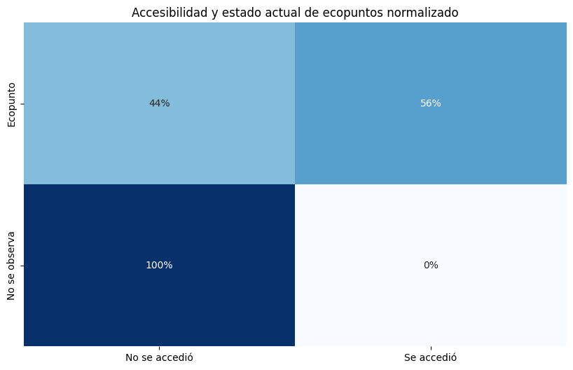

Mientras los ecopuntos funcionaban como tal, a la mayor parte (56%) se pudo acceder, y la otra casi mitad no se pudo acceder pero se pudo observar desde lejos. Eso implica a los ecopuntos que no se encontraban disponibles por el día (no se encuentra todo el tiempo disponible)

# Cartelería

¿Qué relación hay entre la cartelería y la accesibilidad?

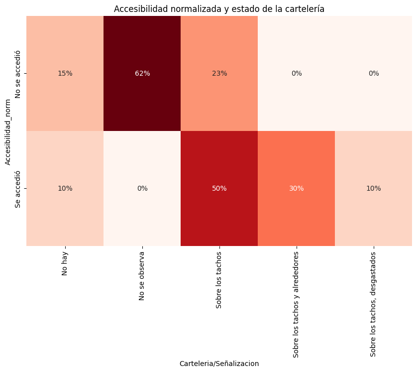

De las que no se accedieron no se pudo observar cartelería en su mayor parte, y de los que se accedieron sólo el 50% tenía sobre los tachos y el 30% sobre los tachos y los alrededores.

# Porcentaje de ocupación de los compartimentos

[figure not shown]

¿Tiene alguna relación con la accesibilidad?

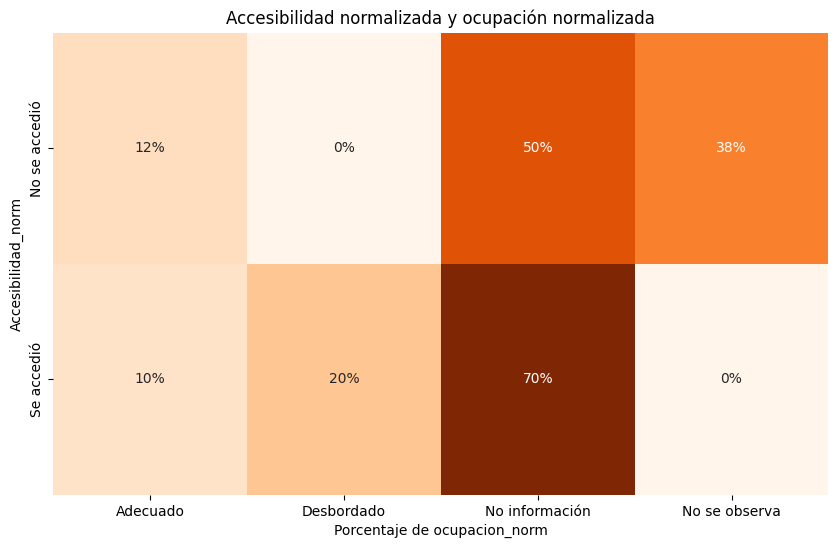

Si bien en su mayor parte no hubo información del porcentaje de ocupación podemos ver que aquellos ecopuntos quesí se accedieron en su mayor parte se pudo acceder, aunque hay un ecopunto que es el que forma parte de Reaccionar y es uno de los que se encontraban desbordados.

[output not shown]